# [Mutation Annotation Format (MAF)](https://docs.gdc.cancer.gov/Encyclopedia/pages/Mutation_Annotation_Format_TCGAv2/#mutation-annotation-format-maf-legacy-tcga-specification)

Mutation Annotation Format (MAF) is a tab-delimited text file with aggregated mutation information from VCF Files and are generated on a project-level. MAF files are produced through the Somatic Aggregation Workflow. The GDC produces MAF files at two permission levels: protected and somatic (or open-access). One MAF file is produced per variant calling pipeline per GDC project. MAFs are produced by aggregating the GDC annotated VCF files generated from one pipeline for one project.

## [Table 1 - File column headers](https://docs.gdc.cancer.gov/Encyclopedia/pages/Mutation_Annotation_Format_TCGAv2/#table-1-file-column-headers)

[output not shown]

```r
# Install pheatmap
# install.packages("pheatmap")
```

```r
library(ggplot2)
library(pheatmap)
```

```r
setwd("C:\\Personal\\BMEG310 2023")
data <- read.delim("data_mutation_lab.txt")
```

```r
colnames(data)
```

```
##   [1] "Hugo_Symbol"                   "Entrez_Gene_Id"
##   [3] "Center"                        "NCBI_Build"
##   [5] "Chromosome"                    "Start_Position"
##   [7] "End_Position"                  "Strand"
##   [9] "Consequence"                   "Variant_Classification"
##  [11] "Variant_Type"                  "Reference_Allele"
##  [13] "Tumor_Seq_Allele1"             "Tumor_Seq_Allele2"
##  [15] "dbSNP_RS"                      "dbSNP_Val_Status"
##  [17] "Tumor_Sample_Barcode"          "Matched_Norm_Sample_Barcode"
##  [19] "Match_Norm_Seq_Allele1"        "Match_Norm_Seq_Allele2"
##  [21] "Tumor_Validation_Allele1"      "Tumor_Validation_Allele2"
##  [23] "Match_Norm_Validation_Allele1" "Match_Norm_Validation_Allele2"
##  [25] "Verification_Status"           "Validation_Status"
##  [27] "Mutation_Status"               "Sequencing_Phase"
##  [29] "Sequence_Source"               "Validation_Method"
```

[output cut: 42 more lines]

## Plotting MAF summary

```r
hugo <- as.data.frame(table(data$Hugo_Symbol))
```

```r
var.class <- as.data.frame(table(data$Variant_Classification))
```

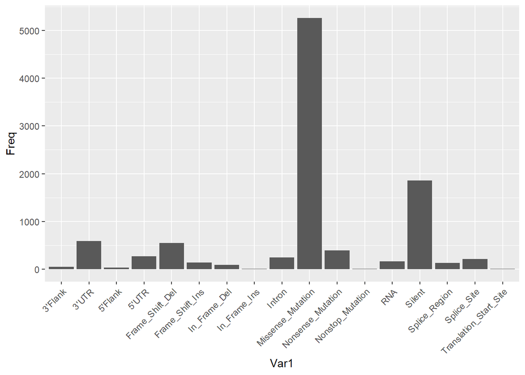

```r
ggplot(data=var.class, aes(x=Var1, y=Freq))+
  geom_col()+
  theme(axis.text.x = element_text(angle = 45,hjust=1))
```

```r
var.class2 <- as.data.frame(table(data$VARIANT_CLASS))
```

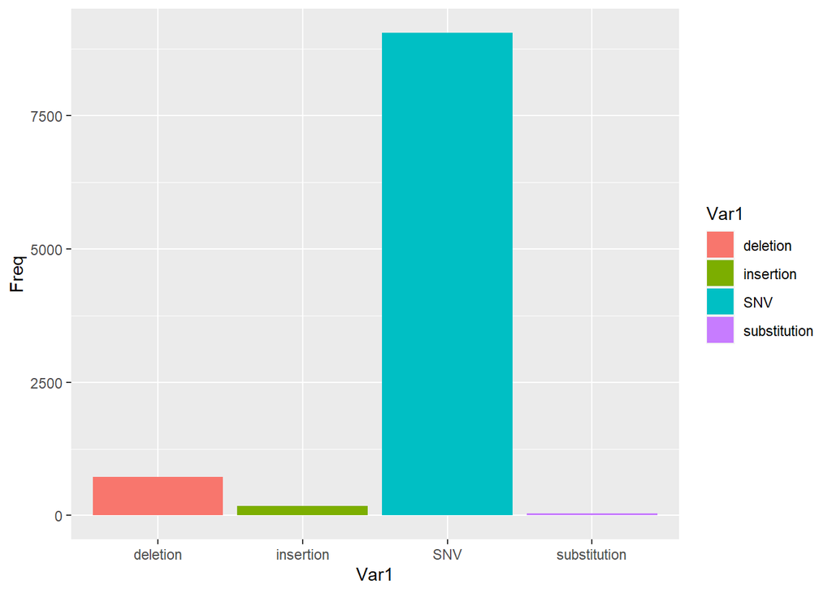

```r
ggplot(data=var.class2, aes(x=Var1, y=Freq))+
  geom_col(aes(fill=Var1))
```

```r
var.type <- as.data.frame(table(data$Variant_Type))
```

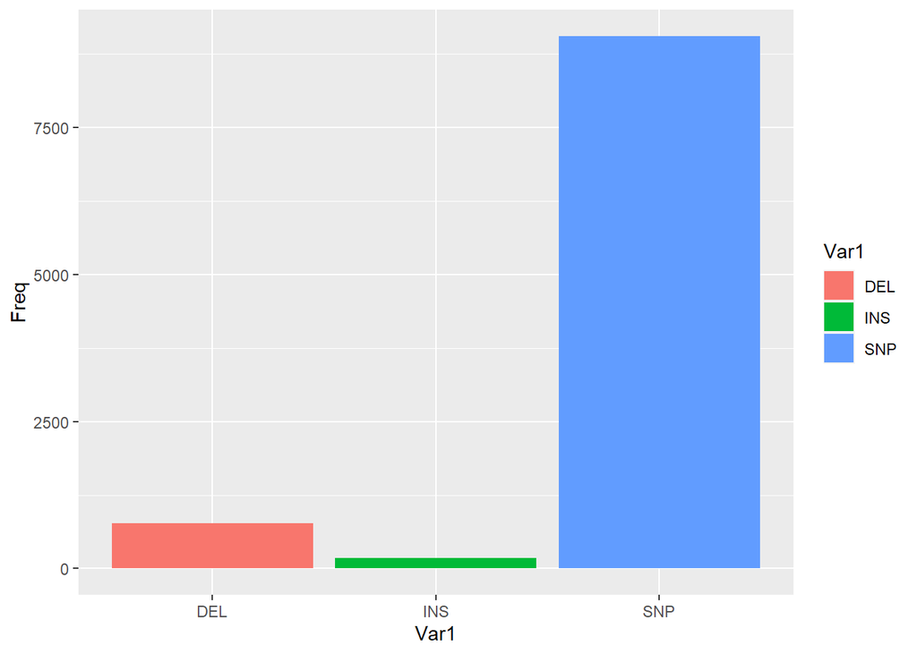

```r
ggplot(data=var.type, aes(x=Var1, y=Freq))+
  geom_col( aes(fill=Var1))
```

```r
sample.name <- as.data.frame(table(data$Tumor_Sample_Barcode))
```

```r
hugo <- as.data.frame(table(data$Hugo_Symbol))

hugo.ordered <- hugo[order(-hugo$Freq),]
```

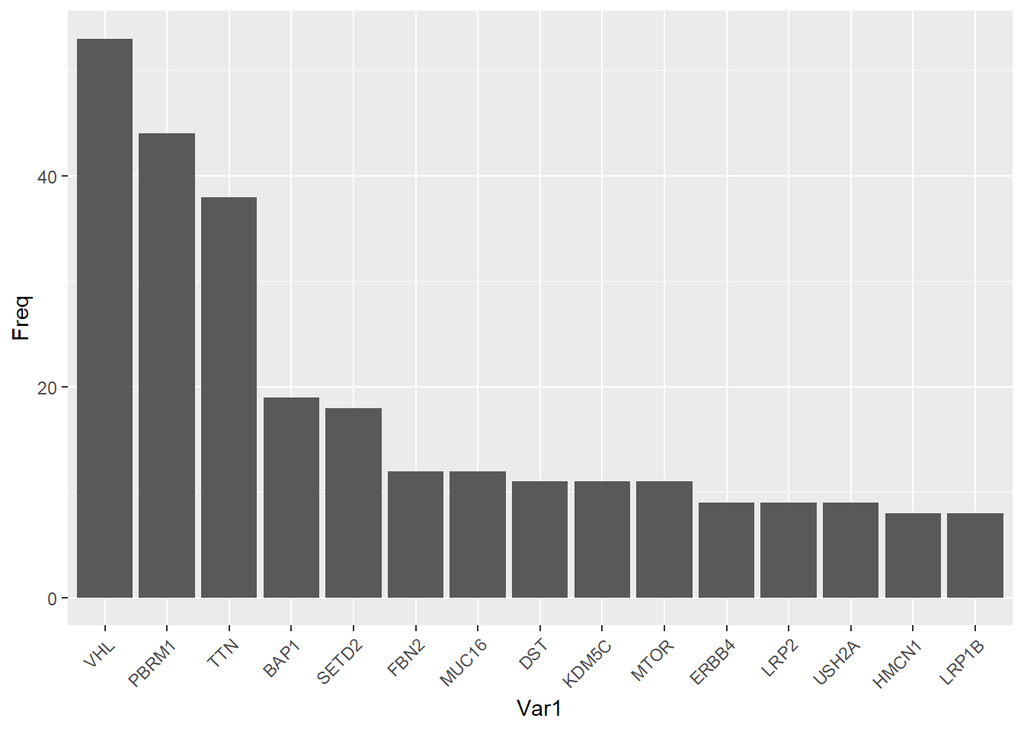

```r
ggplot(data=hugo.ordered[1:15,], aes(x=Var1, y=Freq))+
  geom_col()+
  theme(axis.text.x = element_text(angle = 45,hjust=1))+
  scale_x_discrete(limits = hugo.ordered[1:15,]$Var1)
```

## Generate oncoplot matrix

We create a matrix where the rows represent genes and the columns represent patients. Each cell in the matrix denotes the consequence (`Variant Classification`) of a particular variant. Alternatively, we can construct this matrix using either the VARIANT_CLASS and Variant_Type parameters.

```r
cnv_events = unique(data$Variant_Classification)
oncomat = reshape2::dcast(
  data = data,
  formula = Hugo_Symbol ~ Tumor_Sample_Barcode,
  fun.aggregate = function(x, cnv = cnv_events) {
    x = as.character(x) # >= 2 same/distinct variant classification = Multi_Hit
    xad = x[x %in% cnv]
    xvc = x[!x %in% cnv]

    if (length(xvc) > 0) {
      xvc = ifelse(test = length(xvc) > 1,
                   yes = 'Multi_Hit',
                   no = xvc)
    }

    x = ifelse(
      test = length(xad) > 0,
      yes = paste(xad, xvc, sep = ';'),
      no = xvc
    )
    x = gsub(pattern = ';$',
             replacement = '',
             x = x)
    x = gsub(pattern = '^;',
             replacement = '',
             x = x)
    return(x)
  },
  value.var = 'Variant_Classification',
  fill = '',
  drop = FALSE
)
```

Modify the row label to reflect the Hugo symbol (gene name)

```r
rownames(oncomat) = oncomat$Hugo_Symbol
oncomat <- oncomat[,-1]
```

Reorder the rows according to the occurrence of heavily mutated genes

```r
oncomat.ordered <- oncomat[order(-hugo$Freq),]
```

## Transform the matrix into a binary matrix

You can transform the matrix into a binary matrix, designating mutated genes as 1 and non-mutated genes as 0. Depending on your requirements, you have the flexibility to generate the new matrix accordingly. For instance, in this context, all variant classifications are treated equally, but if you specifically seek ‘missense mutation,’ you would assign 0 to all other classifications and non-mutated genes.

```r
mat <- oncomat.ordered
mat[mat!=""]=1
mat[mat==""]=0
mat <- apply(mat, 2 ,as.numeric)
mat <- as.matrix(mat)
rownames(mat)  <-  row.names(oncomat.ordered)
```

## Draw the heatmap and cluster the patients

Patients can be grouped into clusters based on their most prevalent mutated gene or genes (here I selected the top 3 genes).

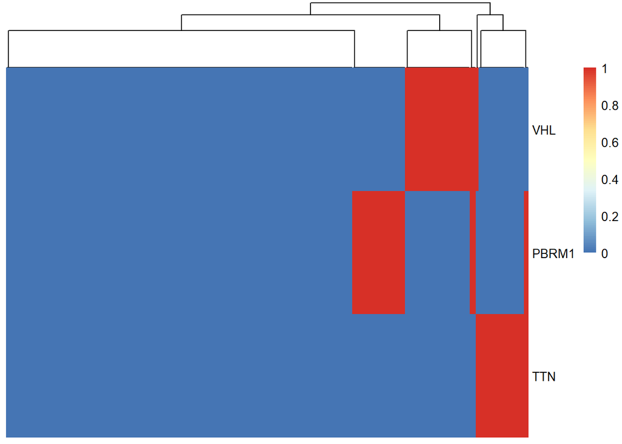

```r
reduce.mat <- mat[1:3,]
res <- pheatmap(reduce.mat,
         cluster_rows = F,
         show_colnames=FALSE)
```

Get the cluster value

```r
cluster <-  as.data.frame(cutree(res$tree_col, k = 2))
```

## Survival analysis

Currently, we have the capability to conduct survival analysis and generate Kaplan-Meier curves through the segmentation of samples according to mutation clusters. To begin, it is crucial to incorporate filters for patients within both the clinical and mutation datasets, accounting for any potential omissions. Upon the application of these filters, the next step involves appending the cluster information to the clinical data as an additional feature, facilitating the seamless execution of survival analysis.